# Microbiome data processing

**Processing phyloseq objects**

Instructions to manipulate microbiome data sets using tools from the [phyloseq package](http://joey711.github.io/phyloseq/) and some extensions from the [microbiome package](https://github.com/microbiome/microbiome), including subsetting, aggregating and filtering.

Load example data:

```r
library(phyloseq)
library(microbiome)
library(knitr)
data(atlas1006)
# Rename the example data (which is a phyloseq object)
pseq <- atlas1006
```

## Summarizing the contents of a phyloseq object

```r
summarize_phyloseq(pseq)
```

```
## Compositional = NO
## 1] Min. number of reads = 1900
## 2] Max. number of reads = 28883
## 3] Total number of reads = 13546564
## 4] Average number of reads = 11769.3866203301
## 5] Median number of reads = 11171
## 7] Sparsity = 0.209002205440086
## 6] Any OTU sum to 1 or less? NO
## 8] Number of singletons = 0
## 9] Percent of OTUs that are singletons 0
## 10] Number of sample variables are: 10
## age
## sex
## nationality
## DNA_extraction_method
## project
## diversity
## bmi_group
## subject
## time
## sample
```

## Retrieving data elements from phyloseq object

A phyloseq object contains OTU table (taxa abundances), sample metadata, taxonomy table (mapping between OTUs and higher-level taxonomic classifications), and phylogenetic tree (relations between the taxa). Some of these are optional.

Pick metadata as data.frame:

```r
meta <- meta(pseq)
```

Taxonomy table:

```r
taxonomy <- tax_table(pseq)
```

Abundances for taxonomic groups (‘OTU table’) as a TaxaxSamples matrix:

```r
# Absolute abundances
otu.absolute <- abundances(pseq)

# Relative abundances
otu.relative <- abundances(pseq, "compositional")
```

Total read counts:

```r
r <- readcount(pseq)
```

Melting phyloseq data for easier plotting:

```r
df <- psmelt(pseq)
kable(head(df))
```

|  | OTU | Sample | Abundance | age | sex | nationality | DNA_extraction_method | project | diversity | bmi_group | subject | time | sample | Phylum | Family | Genus |
| --- | --- | --- | --- | --- | --- | --- | --- | --- | --- | --- | --- | --- | --- | --- | --- | --- |
| 110989 | Prevotella melaninogenica et rel. | Sample-448 | 14961 | 54 | female | CentralEurope | o | 18 | 5.98 | lean | 448 | 0 | Sample-448 | Bacteroidetes | Bacteroidetes | Prevotella melaninogenica et rel. |
| 111380 | Prevotella melaninogenica et rel. | Sample-360 | 14296 | 45 | female | CentralEurope | o | 13 | 5.49 | severeobese | 360 | 0 | Sample-360 | Bacteroidetes | Bacteroidetes | Prevotella melaninogenica et rel. |
| 111232 | Prevotella melaninogenica et rel. | Sample-190 | 13676 | 34 | female | CentralEurope | r | 7 | 6.06 | lean | 190 | 0 | Sample-190 | Bacteroidetes | Bacteroidetes | Prevotella melaninogenica et rel. |
| 111553 | Prevotella melaninogenica et rel. | Sample-743 | 13509 | 52 | male | US | NA | 19 | 5.21 | obese | 743 | 0 | Sample-743 | Bacteroidetes | Bacteroidetes | Prevotella melaninogenica et rel. |
| 110590 | Prevotella melaninogenica et rel. | Sample-366 | 13490 | 52 | female | CentralEurope | o | 15 | 5.63 | obese | 366 | 0 | Sample-366 | Bacteroidetes | Bacteroidetes | Prevotella melaninogenica et rel. |
| 111029 | Prevotella melaninogenica et rel. | Sample-375 | 13384 | 45 | female | CentralEurope | o | 16 | 5.64 | severeobese | 375 | 0 | Sample-375 | Bacteroidetes | Bacteroidetes | Prevotella melaninogenica et rel. |

## Sample operations

Sample names and variables

```r
head(sample_names(pseq))
```

```
## [1] "Sample-1" "Sample-2" "Sample-3" "Sample-4" "Sample-5" "Sample-6"
```

Total OTU abundance in each sample

```r
s <- sample_sums(pseq)
```

Abundance of a given species in each sample

```r
head(abundances(pseq)["Akkermansia",])
```

```
## Sample-1 Sample-2 Sample-3 Sample-4 Sample-5 Sample-6
##       21       36      475       61       34       14
```

Select a subset by metadata fields:

```r
pseq.subset <- subset_samples(pseq, nationality == "AFR")
```

Select a subset by providing sample names:

```r
# Check sample names for African Females in this phyloseq object
s <- rownames(subset(meta(pseq), nationality == "AFR" & sex == "Female"))

# Pick the phyloseq subset with these sample names
pseq.subset2 <- prune_samples(s, pseq)
```

Pick samples at the baseline time points only:

```r
pseq0 <- baseline(pseq)
```

## Data transformations

The microbiome package provides a wrapper for standard sample/OTU transforms. For arbitrary transforms, use the transform_sample_counts function in the phyloseq package. Log10 transform is log(1+x) if the data contains zeroes. Also “Z”, “clr”, “hellinger”, and “shift” are available as common transformations. Relative abundances (note that the input data needs to be in absolute scale, not logarithmic!):

```r
pseq.compositional <- microbiome::transform(pseq, "compositional")
```

The CLR (“clr”) transformation is also available, and comes with a pseudocount to avoid zeroes. An alternative method is to impute the zero-inflated unobserved values. Sometimes a multiplicative Kaplan-Meier smoothing spline (KMSS) replacement, multiplicative lognormal replacement, or multiplicative simple replacement are used. These are available in the zCompositions R package (functions multKM, multLN, and multRepl, respectively). Use at least n.draws = 1000 in practice, here less used to speed up example.

```r
data(dietswap)
x <- dietswap
# Compositional data
x2 <- microbiome::transform(x, "compositional")

# library(zCompositions)
# This would be recommended for compositional zero-inflated data:
# KMSS replacement for zero-inflated compositional values
# x3 <- multKM(transform(x, "compositional"),
#         label = 0, dl = rep(0, ncol(x)), n.draws = 10, n.knots = NULL)
# x4 <- transform(x3, "clr")
```

## Variable operations

Sample variable names

```r
sample_variables(pseq)
```

```
##  [1] "age"                   "sex"
##  [3] "nationality"           "DNA_extraction_method"
##  [5] "project"               "diversity"
##  [7] "bmi_group"             "subject"
##  [9] "time"                  "sample"
```

Pick values for a given variable

```r
head(get_variable(pseq, sample_variables(pseq)[1]))
```

```
## [1] 28 24 52 22 25 42
```

Assign new fields to metadata

```r
# Calculate diversity for samples
div <- alpha(pseq, index = "shannon")

# Assign the estimated diversity to sample metadata
sample_data(pseq)$diversity <- div
```

## Taxa operations

Number of taxa

```r
n <- ntaxa(pseq)
```

Most abundant taxa

```r
topx <- top_taxa(pseq, n = 10)
```

Names

```r
ranks <- rank_names(pseq)  # Taxonomic levels
taxa  <- taxa(pseq)        # Taxa names at the analysed level
```

Subset taxa

```r
pseq.bac <- subset_taxa(pseq, Phylum == "Bacteroidetes")
```

Prune (select) taxa:

```r
# List of Genera in the Bacteroideted Phylum
taxa <- map_levels(NULL, "Phylum", "Genus", pseq)$Bacteroidetes

# With given taxon names
ex2 <- prune_taxa(taxa, pseq)

# Taxa with positive sum across samples
ex3 <- prune_taxa(taxa_sums(pseq) > 0, pseq)
```

Filter by user-specified function values (here variance):

```r
f <- filter_taxa(pseq, function(x) var(x) > 1e-05, TRUE)
```

List unique phylum-level groups:

```r
head(get_taxa_unique(pseq, "Phylum"))
```

```
## [1] "Actinobacteria"  "Firmicutes"      "Proteobacteria"  "Verrucomicrobia"
## [5] "Bacteroidetes"   "Spirochaetes"
```

Pick the taxa abundances for a given sample:

```r
samplename <- sample_names(pseq)[[1]]

# Pick abundances for a particular taxon
tax.abundances <- abundances(pseq)[, samplename]
```

## Merging operations

Aggregate taxa to higher taxonomic levels. This is particularly useful if the phylogenetic tree is missing. When it is available, see [merge_samples, merge_taxa and tax_glom](http://joey711.github.io/phyloseq/merge.html)).

```r
pseq2 <- aggregate_taxa(pseq, "Phylum")
```

Merge the desired taxa into “Other” category. Here, we merge all Bacteroides groups into a single group named Bacteroides.

```r
pseq2 <- merge_taxa2(pseq, pattern = "^Bacteroides", name = "Bacteroides")
```

Merging phyloseq objects with the phyloseq package:

```r
merge_phyloseq(pseqA, pseqB)
```

## Rarification

```r
pseq.rarified <- rarefy_even_depth(pseq)
```

## Taxonomy

Convert between taxonomic levels (here from Genus (Akkermansia) to Phylum (Verrucomicrobia):

```r
m <- map_levels("Akkermansia", "Genus", "Phylum", tax_table(pseq))
print(m)
```

```
## [1] "Verrucomicrobia"
```

## Metadata

Visualize frequencies of given factor (sex) levels within the indicated groups (group):

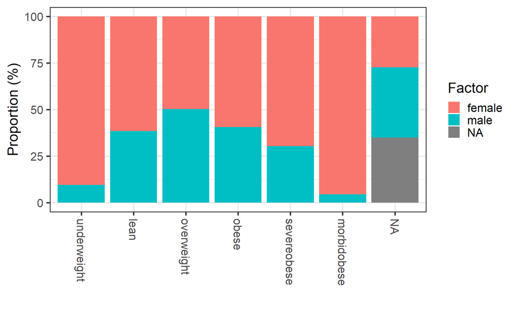

```r
p <- plot_frequencies(sample_data(pseq), "bmi_group", "sex")
print(p)
```

```r
# Retrieving the actual data values:
# kable(head(p@data), digits = 2)
```

Custom functions are provided to cut age or BMI information into discrete classes.

```r
group_bmi(c(22, 28, 31), "standard")
```

```
## [1] lean       overweight obese
## Levels: underweight lean overweight obese severe morbid super
```

```r
group_age(c(17, 41, 102), "decades")
```

```
## [1] [10,20)   [40,50)   [100,110]
## 10 Levels: [10,20) [20,30) [30,40) [40,50) [50,60) [60,70) ... [100,110]
```

Add metadata to a phyloseq object. For reproducibility, we just use the existing metadata in this example, but this can be replaced by another data.frame (samples x fields).

```r
# Example data
data(dietswap)
pseq <- dietswap

# Pick the existing metadata from a phyloseq object
# (or retrieve this from another source)
df <- meta(pseq)

# Merge the metadata back in the phyloseq object
pseq2 <- merge_phyloseq(pseq, sample_data(df))
```

Leo Lahti, Sudarshan Shetty et al. 2019-07-24